# STAT 230

So that’s how a linear model performs if we use it to predict data that was not used in fitting the model. Compared to measures like R-squared, which measure how well a model fits to data that were used in constructing the model, this type of “leave-one-out” “cross validation” is a more “honest” way to estimate how well a model will perform on unseen data.

Here are the analogous plots for degree 2, 3, and 4, polynomials.

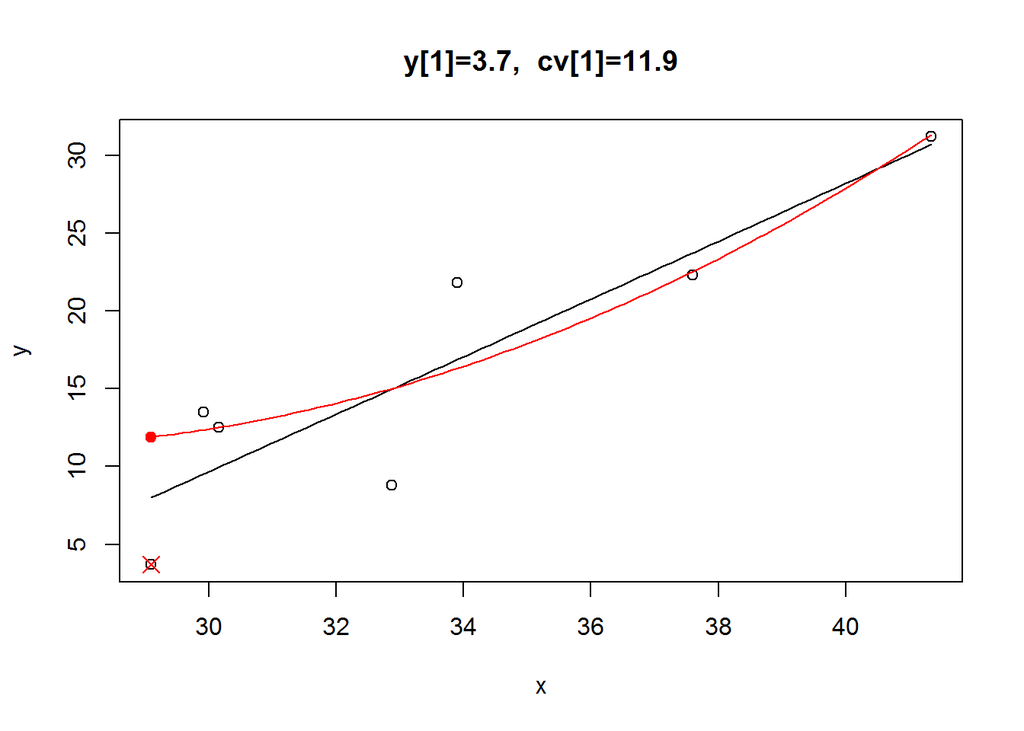

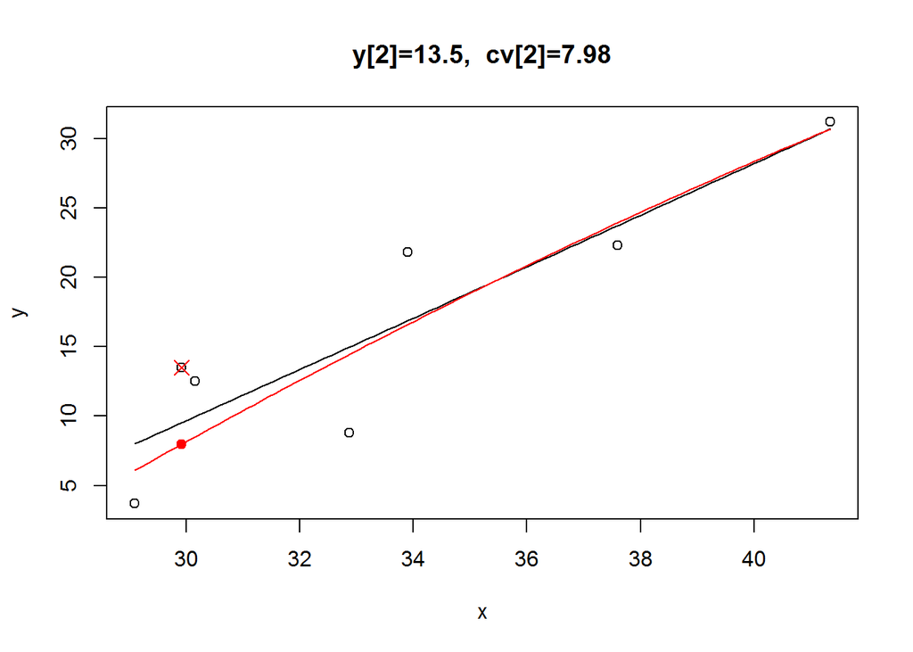

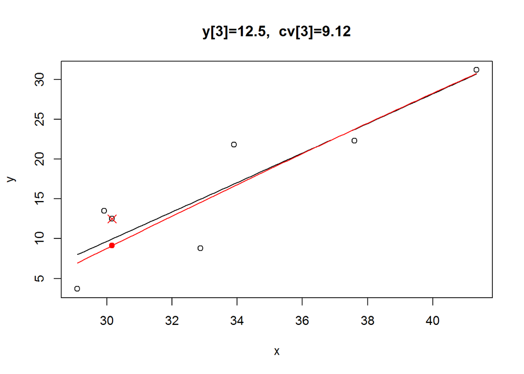

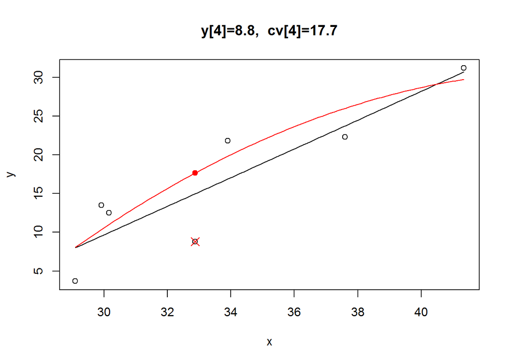

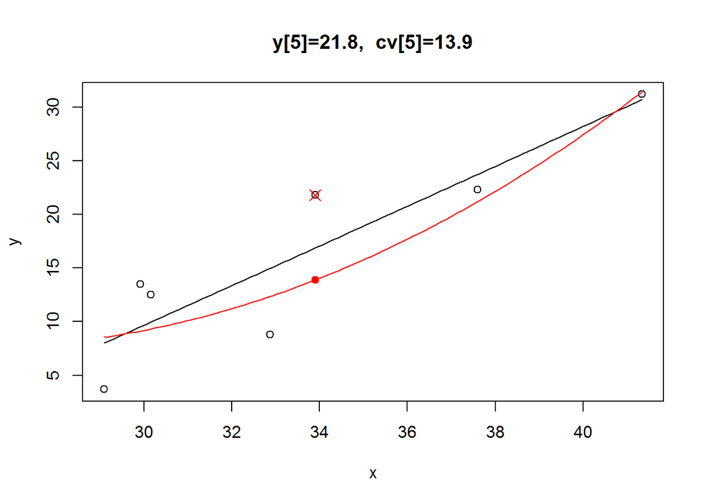

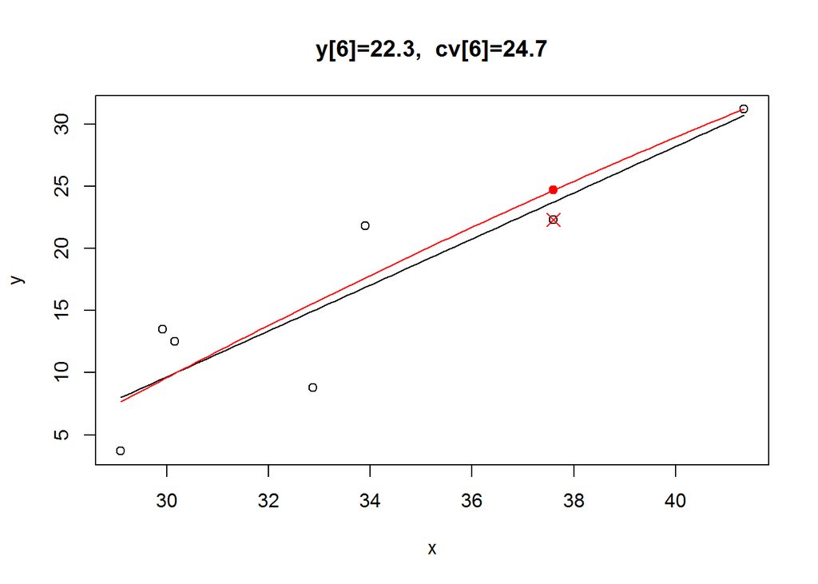

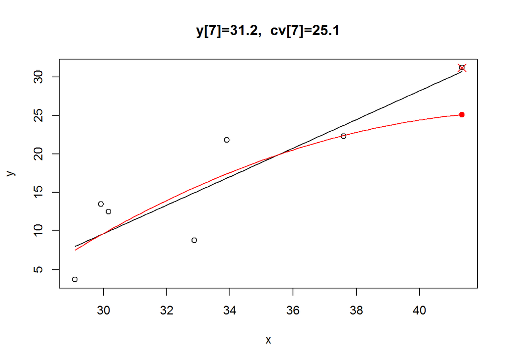

```r
for(i in 1:7)LOO(2,i)
```

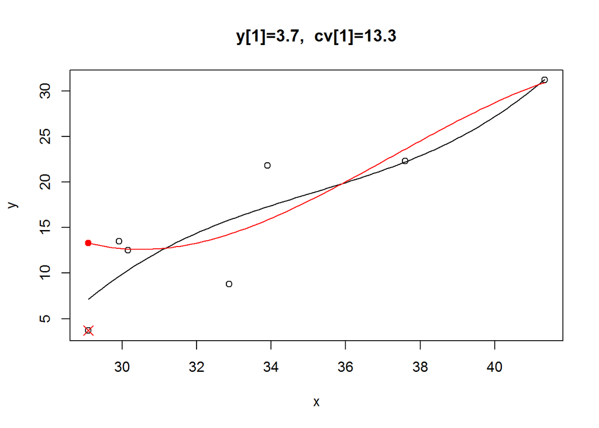

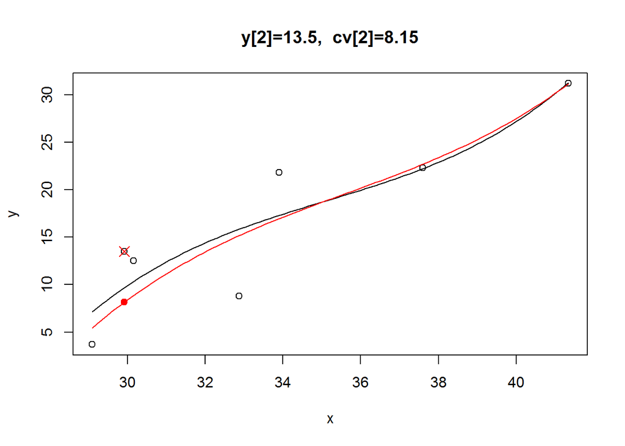

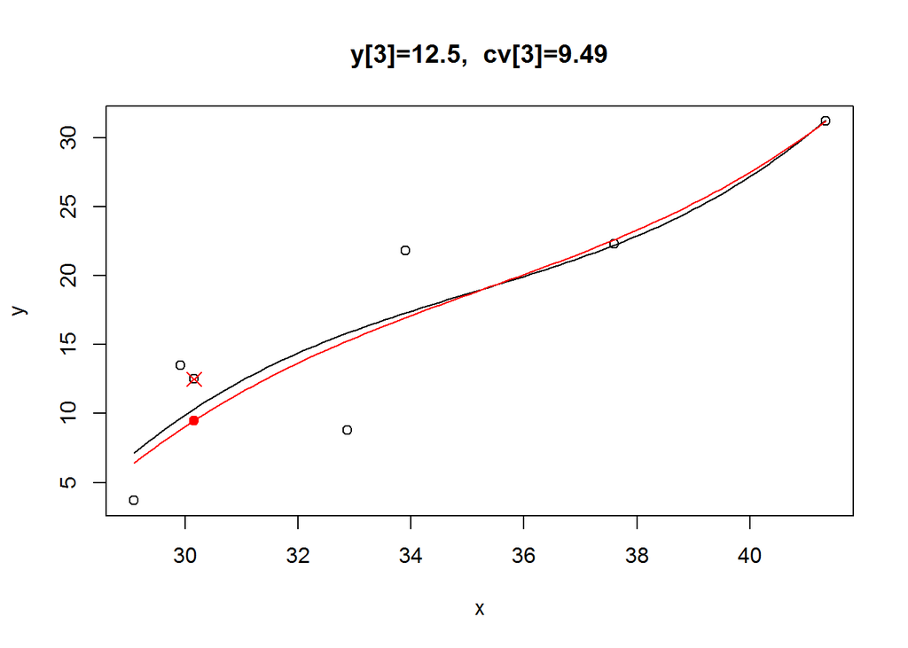

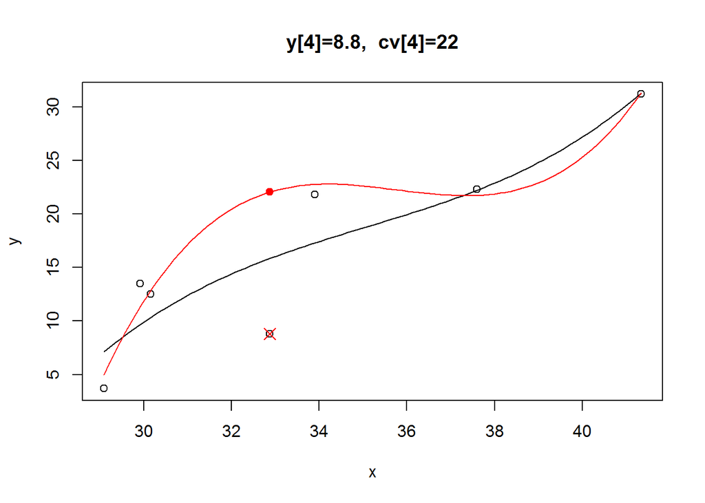

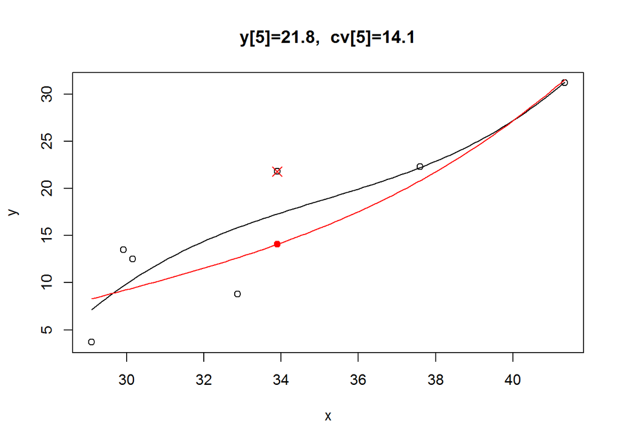

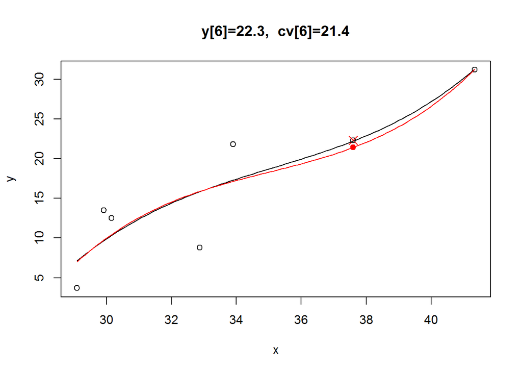

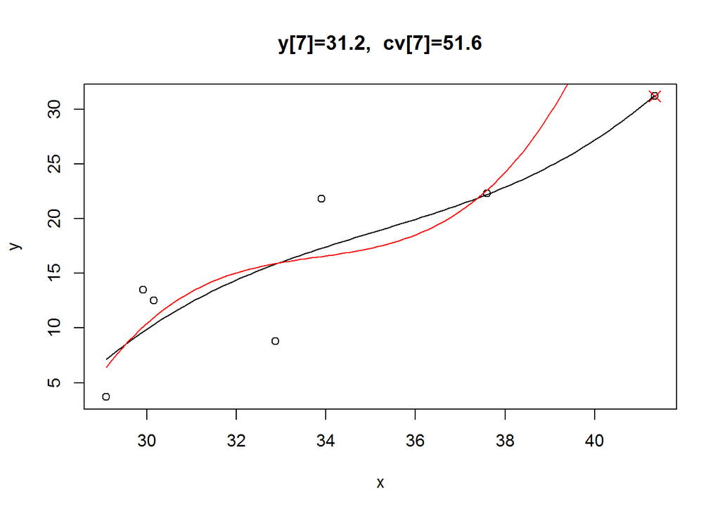

```r
for(i in 1:7)LOO(3,i)
```

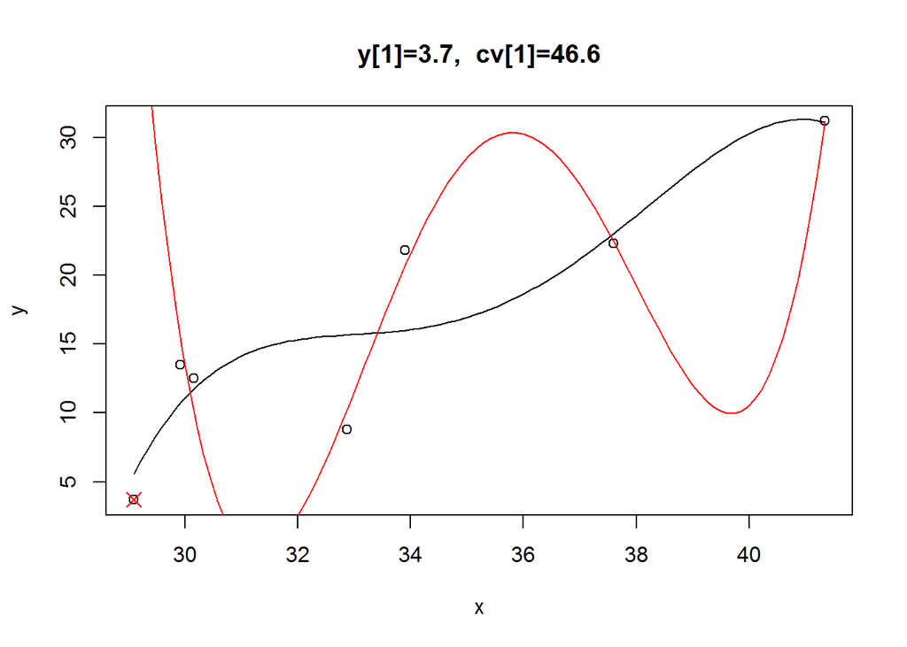

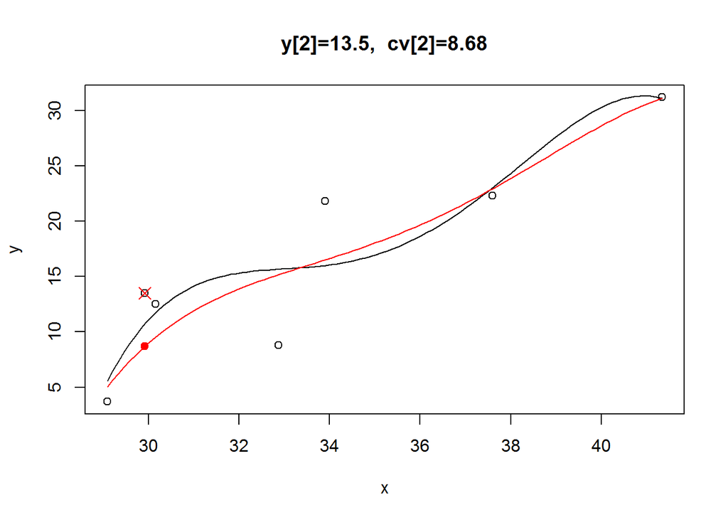

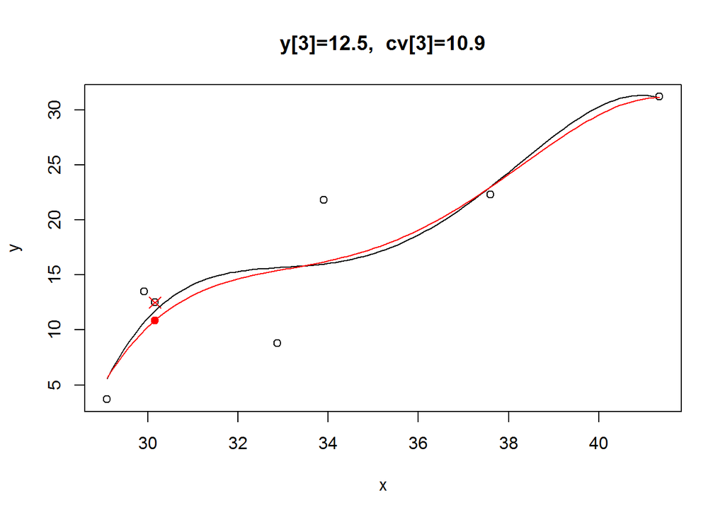

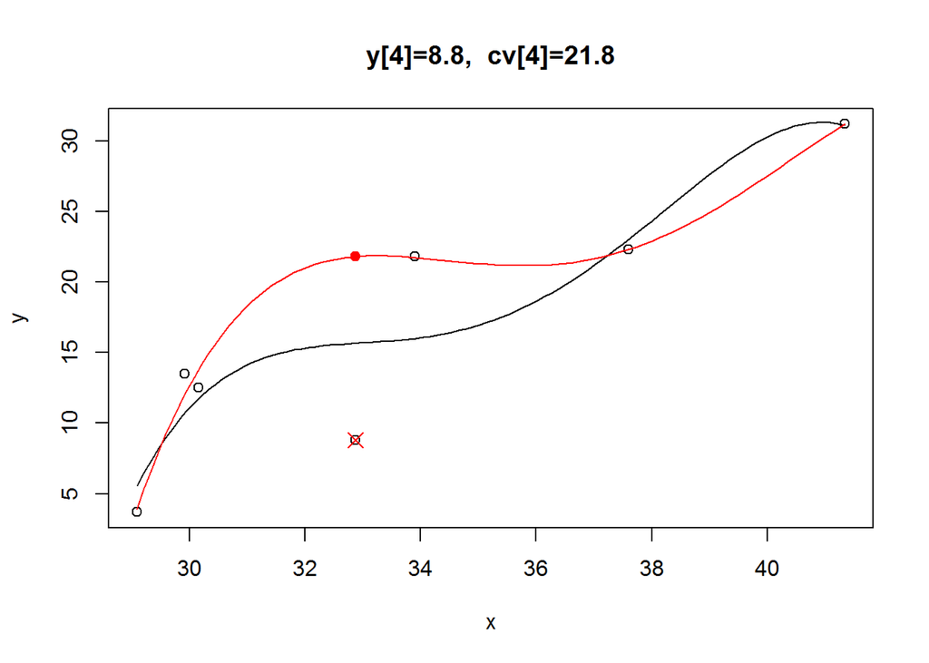

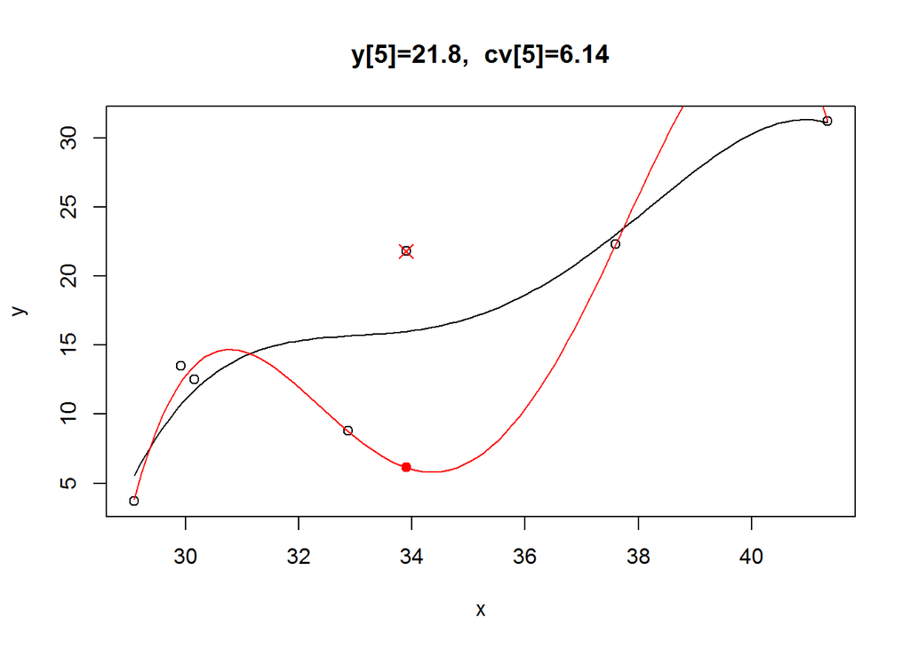

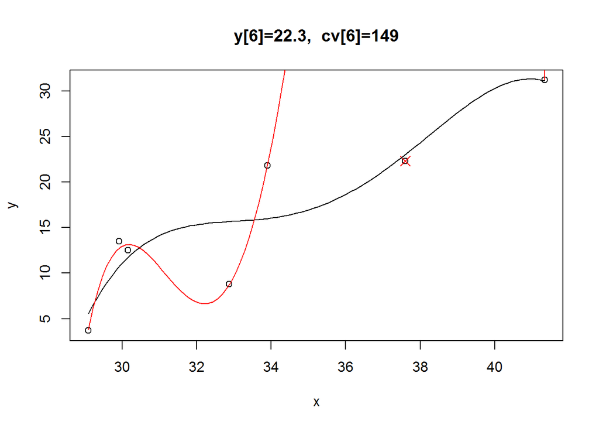

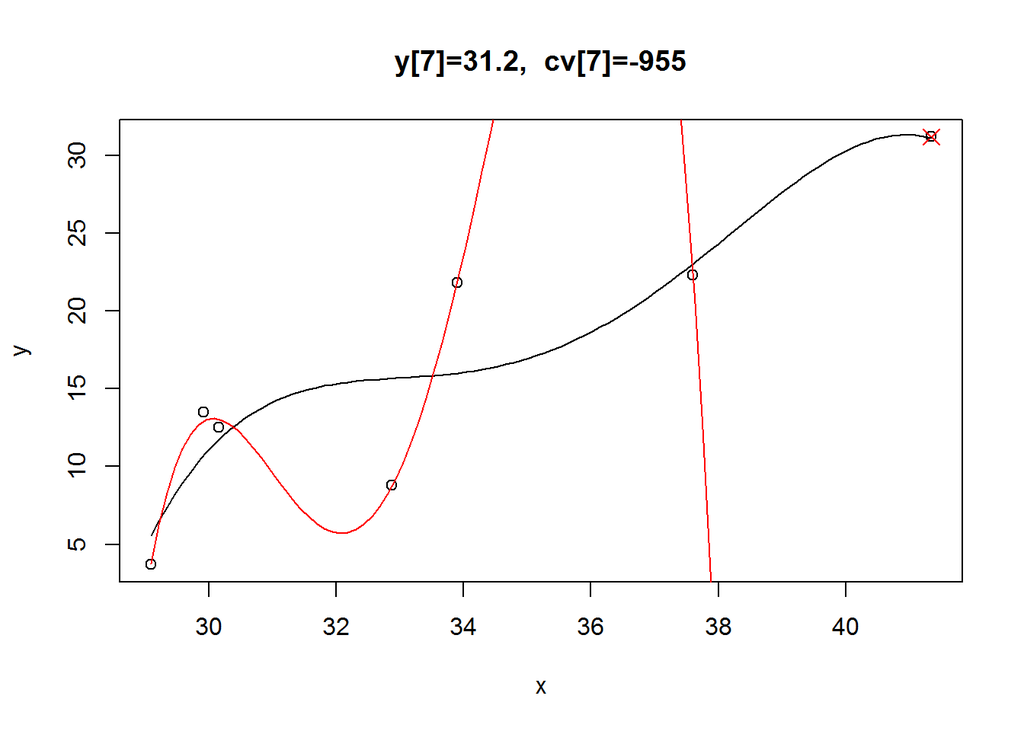

```r
for(i in 1:7)LOO(4,i)
```

Moral of the story: Bigger models are not necessarily better! AIC and cross-validation can give us quantitative guidance.

OK, let’s go back to multiple regression for `bf`.

### Stepwise regression

First let’s remove variables if they have high P values.

```r
mall <- lm(bf ~ ., data=b)
summary(mall)
```

```
##
## Call:
## lm(formula = bf ~ ., data = b)
##
## Residuals:
##      Min       1Q   Median       3Q      Max
## -10.9900  -3.1244  -0.1674   3.0248   9.8648
##
## Coefficients:
##             Estimate Std. Error t value Pr(>|t|)
## (Intercept)  1.68516   23.37412   0.072 0.942587
## age          0.07189    0.03217   2.234 0.026389 *
## weight      -0.01762    0.06714  -0.263 0.793153
## height      -0.24675    0.19114  -1.291 0.197989
## neck        -0.38682    0.23486  -1.647 0.100887
## chest       -0.11919    0.10825  -1.101 0.272004
## abdomen      0.90452    0.09140   9.897  < 2e-16 ***
## hip         -0.15878    0.14586  -1.089 0.277446
## thigh        0.17299    0.14683   1.178 0.239926
## knee        -0.04580    0.24560  -0.186 0.852230
## ankle        0.18502    0.21985   0.842 0.400862
## biceps       0.17968    0.17039   1.054 0.292732
## forearm      0.27605    0.20692   1.334 0.183454
## wrist       -1.80162    0.53304  -3.380 0.000848 ***
## ---
## Signif. codes:  0 '***' 0.001 '**' 0.01 '*' 0.05 '.' 0.1 ' ' 1
##
## Residual standard error: 4.255 on 236 degrees of freedom
## Multiple R-squared:  0.7505, Adjusted R-squared:  0.7368
## F-statistic: 54.61 on 13 and 236 DF,  p-value: < 2.2e-16
```

```r
m <- update(mall, .~.-knee); summary(m)
```

```
##
## Call:
## lm(formula = bf ~ age + weight + height + neck + chest + abdomen +
##     hip + thigh + ankle + biceps + forearm + wrist, data = b)
##
## Residuals:
##      Min       1Q   Median       3Q      Max
## -10.9417  -3.1466  -0.1746   3.0476   9.8304
##
## Coefficients:
##             Estimate Std. Error t value Pr(>|t|)
## (Intercept)  1.39251   23.27384   0.060 0.952340
## age          0.07037    0.03106   2.266 0.024377 *
## weight      -0.01925    0.06644  -0.290 0.772302
## height      -0.25311    0.18769  -1.349 0.178777
## neck        -0.38253    0.23326  -1.640 0.102340
## chest       -0.11822    0.10791  -1.096 0.274385
## abdomen      0.90485    0.09119   9.922  < 2e-16 ***
## hip         -0.16070    0.14520  -1.107 0.269524
## thigh        0.16517    0.14043   1.176 0.240703
## ankle        0.17752    0.21569   0.823 0.411321
## biceps       0.18124    0.16984   1.067 0.287012
## forearm      0.27399    0.20620   1.329 0.185207
## wrist       -1.80833    0.53074  -3.407 0.000771 ***
## ---
## Signif. codes:  0 '***' 0.001 '**' 0.01 '*' 0.05 '.' 0.1 ' ' 1
##
## Residual standard error: 4.247 on 237 degrees of freedom
## Multiple R-squared:  0.7505, Adjusted R-squared:  0.7378
## F-statistic: 59.39 on 12 and 237 DF,  p-value: < 2.2e-16
```

```r
m <- update(m, .~.-weight); summary(m)
```

```
##
## Call:
## lm(formula = bf ~ age + height + neck + chest + abdomen + hip +
##     thigh + ankle + biceps + forearm + wrist, data = b)
##
## Residuals:
##      Min       1Q   Median       3Q      Max
## -10.9342  -3.1666  -0.2152   3.0069   9.8783
##
## Coefficients:
##             Estimate Std. Error t value Pr(>|t|)
## (Intercept)  7.66457    8.52335   0.899 0.369432
## age          0.07197    0.03050   2.359 0.019109 *
## height      -0.29297    0.12741  -2.299 0.022351 *
## neck        -0.39903    0.22576  -1.767 0.078432 .
## chest       -0.13534    0.09011  -1.502 0.134470
## abdomen      0.89514    0.08465  10.575  < 2e-16 ***
## hip         -0.17883    0.13077  -1.368 0.172743
## thigh        0.15553    0.13616   1.142 0.254518
## ankle        0.16442    0.21049   0.781 0.435510
## biceps       0.17172    0.16631   1.033 0.302877
## forearm      0.26623    0.20406   1.305 0.193265
## wrist       -1.83656    0.52072  -3.527 0.000504 ***
## ---
## Signif. codes:  0 '***' 0.001 '**' 0.01 '*' 0.05 '.' 0.1 ' ' 1
##
## Residual standard error: 4.239 on 238 degrees of freedom
## Multiple R-squared:  0.7504, Adjusted R-squared:  0.7388
## F-statistic: 65.04 on 11 and 238 DF,  p-value: < 2.2e-16
```

```r
m <- update(m, .~.-ankle); summary(m)
```

```
##
## Call:
## lm(formula = bf ~ age + height + neck + chest + abdomen + hip +
##     thigh + biceps + forearm + wrist, data = b)
##
## Residuals:
##      Min       1Q   Median       3Q      Max
## -10.7596  -3.1177  -0.1717   2.9837   9.8009
##
## Coefficients:
##             Estimate Std. Error t value Pr(>|t|)
## (Intercept)  7.68505    8.51635   0.902 0.367759
## age          0.06951    0.03032   2.293 0.022718 *
## height      -0.27993    0.12621  -2.218 0.027499 *
## neck        -0.41542    0.22460  -1.850 0.065613 .
## chest       -0.12989    0.08977  -1.447 0.149248
## abdomen      0.89241    0.08450  10.560  < 2e-16 ***
## hip         -0.17419    0.13053  -1.335 0.183307
## thigh        0.16457    0.13556   1.214 0.225946
## biceps       0.16953    0.16615   1.020 0.308618
## forearm      0.27007    0.20384   1.325 0.186462
## wrist       -1.71283    0.49564  -3.456 0.000649 ***
## ---
## Signif. codes:  0 '***' 0.001 '**' 0.01 '*' 0.05 '.' 0.1 ' ' 1
##
## Residual standard error: 4.235 on 239 degrees of freedom
## Multiple R-squared:  0.7497, Adjusted R-squared:  0.7393
## F-statistic:  71.6 on 10 and 239 DF,  p-value: < 2.2e-16
```

```r
m <- update(m, .~.-biceps); summary(m)
```

```
##
## Call:
## lm(formula = bf ~ age + height + neck + chest + abdomen + hip +
##     thigh + forearm + wrist, data = b)
##
## Residuals:
##      Min       1Q   Median       3Q      Max
## -10.7569  -3.0496  -0.1797   2.9704   9.9301
##
## Coefficients:
##             Estimate Std. Error t value Pr(>|t|)
## (Intercept)  6.25092    8.40028   0.744 0.457524
## age          0.07043    0.03030   2.324 0.020954 *
## height      -0.27857    0.12622  -2.207 0.028255 *
## neck        -0.38777    0.22298  -1.739 0.083316 .
## chest       -0.11374    0.08837  -1.287 0.199326
## abdomen      0.88543    0.08423  10.511  < 2e-16 ***
## hip         -0.17552    0.13053  -1.345 0.179998
## thigh        0.20497    0.12966   1.581 0.115223
## forearm      0.33459    0.19380   1.726 0.085548 .
## wrist       -1.67892    0.49457  -3.395 0.000804 ***
## ---
## Signif. codes:  0 '***' 0.001 '**' 0.01 '*' 0.05 '.' 0.1 ' ' 1
##
## Residual standard error: 4.236 on 240 degrees of freedom
## Multiple R-squared:  0.7486, Adjusted R-squared:  0.7392
## F-statistic: 79.42 on 9 and 240 DF,  p-value: < 2.2e-16
```

```r
m <- update(m, .~.-chest); summary(m)
```

```
##
## Call:
## lm(formula = bf ~ age + height + neck + abdomen + hip + thigh +
##     forearm + wrist, data = b)
##
## Residuals:
##     Min      1Q  Median      3Q     Max
## -10.805  -2.977  -0.228   3.104  10.165
##
## Coefficients:
##             Estimate Std. Error t value Pr(>|t|)
## (Intercept)  5.04038    8.35881   0.603 0.547074
## age          0.07258    0.03030   2.396 0.017361 *
## height      -0.26807    0.12612  -2.125 0.034567 *
## neck        -0.45133    0.21774  -2.073 0.039252 *
## abdomen      0.82271    0.06880  11.958  < 2e-16 ***
## hip         -0.19488    0.12984  -1.501 0.134689
## thigh        0.22387    0.12900   1.735 0.083943 .
## forearm      0.29550    0.19166   1.542 0.124440
## wrist       -1.73072    0.49360  -3.506 0.000542 ***
## ---
## Signif. codes:  0 '***' 0.001 '**' 0.01 '*' 0.05 '.' 0.1 ' ' 1
##
## Residual standard error: 4.241 on 241 degrees of freedom
## Multiple R-squared:  0.7469, Adjusted R-squared:  0.7385
## F-statistic:  88.9 on 8 and 241 DF,  p-value: < 2.2e-16
```

```r
m <- update(m, .~.-hip); summary(m)
```

```
##
## Call:
## lm(formula = bf ~ age + height + neck + abdomen + thigh + forearm +
##     wrist, data = b)
##
## Residuals:
##      Min       1Q   Median       3Q      Max
## -10.7562  -3.1358  -0.1182   3.1897   9.7548
##
## Coefficients:
##             Estimate Std. Error t value Pr(>|t|)
## (Intercept)  2.54110    8.21244   0.309  0.75727
## age          0.08110    0.02984   2.718  0.00704 **
## height      -0.32205    0.12120  -2.657  0.00840 **
## neck        -0.41840    0.21719  -1.926  0.05523 .
## abdomen      0.75564    0.05245  14.408  < 2e-16 ***
## thigh        0.11994    0.10912   1.099  0.27279
## forearm      0.28785    0.19209   1.499  0.13530
## wrist       -1.85097    0.48831  -3.791  0.00019 ***
## ---
## Signif. codes:  0 '***' 0.001 '**' 0.01 '*' 0.05 '.' 0.1 ' ' 1
##
## Residual standard error: 4.252 on 242 degrees of freedom
## Multiple R-squared:  0.7445, Adjusted R-squared:  0.7371
## F-statistic: 100.8 on 7 and 242 DF,  p-value: < 2.2e-16
```

```r
m <- update(m, .~.-thigh); summary(m)
```

```
##
## Call:
## lm(formula = bf ~ age + height + neck + abdomen + forearm + wrist,
##     data = b)
##
## Residuals:
##      Min       1Q   Median       3Q      Max
## -10.5806  -3.0089  -0.1903   3.1722   9.6745
##
## Coefficients:
##             Estimate Std. Error t value Pr(>|t|)
## (Intercept)  3.60659    8.15853   0.442 0.658836
## age          0.06296    0.02487   2.532 0.011985 *
## height      -0.31499    0.12108  -2.601 0.009852 **
## neck        -0.39136    0.21589  -1.813 0.071095 .
## abdomen      0.79264    0.04023  19.703  < 2e-16 ***
## forearm      0.31509    0.19057   1.653 0.099541 .
## wrist       -1.78853    0.48520  -3.686 0.000281 ***
## ---
## Signif. codes:  0 '***' 0.001 '**' 0.01 '*' 0.05 '.' 0.1 ' ' 1
##
## Residual standard error: 4.254 on 243 degrees of freedom
## Multiple R-squared:  0.7433, Adjusted R-squared:  0.7369
## F-statistic: 117.2 on 6 and 243 DF,  p-value: < 2.2e-16
```

```r
m <- update(m, .~.-forearm); summary(m)
```

```
##
## Call:
## lm(formula = bf ~ age + height + neck + abdomen + wrist, data = b)
##
## Residuals:
##     Min      1Q  Median      3Q     Max
## -10.434  -2.997  -0.277   3.326   9.985
##
## Coefficients:
##             Estimate Std. Error t value Pr(>|t|)
## (Intercept)  4.62108    8.16427   0.566 0.571905
## age          0.05163    0.02399   2.152 0.032385 *
## height      -0.31378    0.12151  -2.582 0.010395 *
## neck        -0.28652    0.20710  -1.384 0.167767
## abdomen      0.80118    0.04004  20.011  < 2e-16 ***
## wrist       -1.58685    0.47129  -3.367 0.000883 ***
## ---
## Signif. codes:  0 '***' 0.001 '**' 0.01 '*' 0.05 '.' 0.1 ' ' 1
##
## Residual standard error: 4.269 on 244 degrees of freedom
## Multiple R-squared:  0.7404, Adjusted R-squared:  0.7351
## F-statistic: 139.2 on 5 and 244 DF,  p-value: < 2.2e-16
```

```r
m <- update(m, .~.-neck); summary(m)
```

```
##
## Call:
## lm(formula = bf ~ age + height + abdomen + wrist, data = b)
##
## Residuals:
##      Min       1Q   Median       3Q      Max
## -10.4030  -2.9975  -0.4326   3.3896   9.3637
##
## Coefficients:
##             Estimate Std. Error t value Pr(>|t|)
## (Intercept)  2.90033    8.08402   0.359   0.7201
## age          0.05602    0.02382   2.351   0.0195 *
## height      -0.32299    0.12155  -2.657   0.0084 **
## abdomen      0.77097    0.03362  22.932  < 2e-16 ***
## wrist       -1.91138    0.40953  -4.667 5.03e-06 ***
## ---
## Signif. codes:  0 '***' 0.001 '**' 0.01 '*' 0.05 '.' 0.1 ' ' 1
##
## Residual standard error: 4.277 on 245 degrees of freedom
## Multiple R-squared:  0.7383, Adjusted R-squared:  0.7341
## F-statistic: 172.8 on 4 and 245 DF,  p-value: < 2.2e-16
```

That may be a nice idea, but why use P values and why use an arbitrary threshold of .05? Better to use AIC:

```r
(d <- drop1(mall))
```

```
## Single term deletions
##
## Model:
## bf ~ age + weight + height + neck + chest + abdomen + hip + thigh +
##     knee + ankle + biceps + forearm + wrist
##         Df Sum of Sq    RSS    AIC
## <none>               4273.7 737.70
## age      1     90.42 4364.1 740.93
## weight   1      1.25 4275.0 735.77
## height   1     30.18 4303.9 737.45
## neck     1     49.12 4322.9 738.55
## chest    1     21.95 4295.7 736.98
## abdomen  1   1773.63 6047.4 822.48
## hip      1     21.46 4295.2 736.95
## thigh    1     25.14 4298.9 737.16
## knee     1      0.63 4274.4 735.73
## ankle    1     12.83 4286.6 736.44
## biceps   1     20.14 4293.9 736.87
## forearm  1     32.23 4306.0 737.57
## wrist    1    206.87 4480.6 747.51
```

```r
names(d)
```

```
## [1] "Df"        "Sum of Sq" "RSS"       "AIC"
```

```r
d[order(d$AIC),]
```

```
## Single term deletions
##
## Model:
## bf ~ age + weight + height + neck + chest + abdomen + hip + thigh +
##     knee + ankle + biceps + forearm + wrist
##         Df Sum of Sq    RSS    AIC
## knee     1      0.63 4274.4 735.73
## weight   1      1.25 4275.0 735.77
## ankle    1     12.83 4286.6 736.44
## biceps   1     20.14 4293.9 736.87
## hip      1     21.46 4295.2 736.95
## chest    1     21.95 4295.7 736.98
## thigh    1     25.14 4298.9 737.16
## height   1     30.18 4303.9 737.45
## forearm  1     32.23 4306.0 737.57
## <none>               4273.7 737.70
## neck     1     49.12 4322.9 738.55
## age      1     90.42 4364.1 740.93
## wrist    1    206.87 4480.6 747.51
## abdomen  1   1773.63 6047.4 822.48
```

```r
d <- drop1(mall); d[order(d$AIC),]
```

```
## Single term deletions
##
## Model:
## bf ~ age + weight + height + neck + chest + abdomen + hip + thigh +
##     knee + ankle + biceps + forearm + wrist
##         Df Sum of Sq    RSS    AIC
## knee     1      0.63 4274.4 735.73
## weight   1      1.25 4275.0 735.77
## ankle    1     12.83 4286.6 736.44
## biceps   1     20.14 4293.9 736.87
## hip      1     21.46 4295.2 736.95
## chest    1     21.95 4295.7 736.98
## thigh    1     25.14 4298.9 737.16
## height   1     30.18 4303.9 737.45
## forearm  1     32.23 4306.0 737.57
## <none>               4273.7 737.70
## neck     1     49.12 4322.9 738.55
## age      1     90.42 4364.1 740.93
## wrist    1    206.87 4480.6 747.51
## abdomen  1   1773.63 6047.4 822.48
```

```r
m <- update(mall, .~.-knee); d <- drop1(m); d[order(d$AIC),]
```

```
## Single term deletions
##
## Model:
## bf ~ age + weight + height + neck + chest + abdomen + hip + thigh +
##     ankle + biceps + forearm + wrist
##         Df Sum of Sq    RSS    AIC
## weight   1      1.51 4275.9 733.82
## ankle    1     12.22 4286.6 734.45
## biceps   1     20.54 4294.9 734.93
## chest    1     21.65 4296.0 735.00
## hip      1     22.09 4296.5 735.02
## thigh    1     24.95 4299.3 735.19
## forearm  1     31.84 4306.2 735.59
## height   1     32.80 4307.2 735.64
## <none>               4274.4 735.73
## neck     1     48.51 4322.9 736.55
## age      1     92.58 4366.9 739.09
## wrist    1    209.37 4483.7 745.69
## abdomen  1   1775.58 6049.9 820.59
```

```r
m <- update(m, .~.-weight); d <- drop1(m); d[order(d$AIC),]
```

```
## Single term deletions
##
## Model:
## bf ~ age + height + neck + chest + abdomen + hip + thigh + ankle +
##     biceps + forearm + wrist
##         Df Sum of Sq    RSS    AIC
## ankle    1     10.96 4286.8 732.46
## biceps   1     19.15 4295.0 732.94
## thigh    1     23.44 4299.3 733.19
## forearm  1     30.58 4306.5 733.60
## hip      1     33.60 4309.5 733.78
## <none>               4275.9 733.82
## chest    1     40.52 4316.4 734.18
## neck     1     56.12 4332.0 735.08
## height   1     94.99 4370.9 737.31
## age      1    100.02 4375.9 737.60
## wrist    1    223.48 4499.4 744.56
## abdomen  1   2009.17 6285.0 828.12
```

```r
m <- update(m, .~.-ankle); d <- drop1(m); d[order(d$AIC),]
```

```
## Single term deletions
##
## Model:
## bf ~ age + height + neck + chest + abdomen + hip + thigh + biceps +
##     forearm + wrist
##         Df Sum of Sq    RSS    AIC
## biceps   1     18.67 4305.5 731.55
## thigh    1     26.43 4313.3 732.00
## forearm  1     31.49 4318.3 732.29
## hip      1     31.94 4318.8 732.32
## <none>               4286.8 732.46
## chest    1     37.55 4324.4 732.64
## neck     1     61.36 4348.2 734.01
## height   1     88.24 4375.1 735.55
## age      1     94.31 4381.1 735.90
## wrist    1    214.21 4501.0 742.65
## abdomen  1   2000.35 6287.2 826.20
```

```r
m <- update(m, .~.-biceps); d <- drop1(m); d[order(d$AIC),]
```

```
## Single term deletions
##
## Model:
## bf ~ age + height + neck + chest + abdomen + hip + thigh + forearm +
##     wrist
##         Df Sum of Sq    RSS    AIC
## chest    1     29.72 4335.2 731.27
## hip      1     32.44 4337.9 731.42
## <none>               4305.5 731.55
## thigh    1     44.83 4350.3 732.14
## forearm  1     53.47 4359.0 732.63
## neck     1     54.25 4359.8 732.68
## height   1     87.39 4392.9 734.57
## age      1     96.90 4402.4 735.11
## wrist    1    206.74 4512.2 741.27
## abdomen  1   1982.17 6287.7 824.22
```

```r
m <- update(m, .~.-chest); d <- drop1(m); d[order(d$AIC),]
```

```
## Single term deletions
##
## Model:
## bf ~ age + height + neck + abdomen + hip + thigh + forearm +
##     wrist
##         Df Sum of Sq    RSS    AIC
## <none>               4335.2 731.27
## hip      1     40.52 4375.7 731.59
## forearm  1     42.76 4378.0 731.72
## thigh    1     54.18 4389.4 732.37
## neck     1     77.29 4412.5 733.68
## height   1     81.26 4416.5 733.91
## age      1    103.23 4438.5 735.15
## wrist    1    221.16 4556.4 741.71
## abdomen  1   2572.22 6907.4 845.72
```

```r
m
```

```
##
## Call:
## lm(formula = bf ~ age + height + neck + abdomen + hip + thigh +
##     forearm + wrist, data = b)
##
## Coefficients:
## (Intercept)          age       height         neck      abdomen
##     5.04038      0.07258     -0.26807     -0.45133      0.82271
##         hip        thigh      forearm        wrist
##    -0.19488      0.22387      0.29550     -1.73072
```

```r
# AIC ends up with a model bigger than backwards
# stepwise using .05 threshold for P value
```

A “stepwise regression” function that automates what we just did:

```r
msb <- step(mall, direction="backward")
```

```
## Start:  AIC=737.7
## bf ~ age + weight + height + neck + chest + abdomen + hip + thigh +
##     knee + ankle + biceps + forearm + wrist
##
##           Df Sum of Sq    RSS    AIC
## - knee     1      0.63 4274.4 735.73
## - weight   1      1.25 4275.0 735.77
## - ankle    1     12.83 4286.6 736.44
## - biceps   1     20.14 4293.9 736.87
## - hip      1     21.46 4295.2 736.95
## - chest    1     21.95 4295.7 736.98
## - thigh    1     25.14 4298.9 737.16
## - height   1     30.18 4303.9 737.45
## - forearm  1     32.23 4306.0 737.57
## <none>                 4273.7 737.70
## - neck     1     49.12 4322.9 738.55
## - age      1     90.42 4364.1 740.93
## - wrist    1    206.87 4480.6 747.51
## - abdomen  1   1773.63 6047.4 822.48
##
## Step:  AIC=735.73
## bf ~ age + weight + height + neck + chest + abdomen + hip + thigh +
##     ankle + biceps + forearm + wrist
##
##           Df Sum of Sq    RSS    AIC
## - weight   1      1.51 4275.9 733.82
## - ankle    1     12.22 4286.6 734.45
## - biceps   1     20.54 4294.9 734.93
## - chest    1     21.65 4296.0 735.00
## - hip      1     22.09 4296.5 735.02
## - thigh    1     24.95 4299.3 735.19
## - forearm  1     31.84 4306.2 735.59
## - height   1     32.80 4307.2 735.64
## <none>                 4274.4 735.73
## - neck     1     48.51 4322.9 736.55
## - age      1     92.58 4366.9 739.09
## - wrist    1    209.37 4483.7 745.69
## - abdomen  1   1775.58 6049.9 820.59
##
## Step:  AIC=733.82
```

[output cut: 49 more lines]

```
##
## Step:  AIC=731.27
## bf ~ age + height + neck + abdomen + hip + thigh + forearm +
##     wrist
##
##           Df Sum of Sq    RSS    AIC
## <none>                 4335.2 731.27
## - hip      1     40.52 4375.7 731.59
## - forearm  1     42.76 4378.0 731.72
## - thigh    1     54.18 4389.4 732.37
## - neck     1     77.29 4412.5 733.68
## - height   1     81.26 4416.5 733.91
## - age      1    103.23 4438.5 735.15
## - wrist    1    221.16 4556.4 741.71
## - abdomen  1   2572.22 6907.4 845.72
```

```r
msb
```

```
##
## Call:
## lm(formula = bf ~ age + height + neck + abdomen + hip + thigh +
##     forearm + wrist, data = b)
##
## Coefficients:
## (Intercept)          age       height         neck      abdomen
##     5.04038      0.07258     -0.26807     -0.45133      0.82271
##         hip        thigh      forearm        wrist
##    -0.19488      0.22387      0.29550     -1.73072
```

```r
m
```

```
##
## Call:
## lm(formula = bf ~ age + height + neck + abdomen + hip + thigh +
##     forearm + wrist, data = b)
##
## Coefficients:
## (Intercept)          age       height         neck      abdomen
##     5.04038      0.07258     -0.26807     -0.45133      0.82271
##         hip        thigh      forearm        wrist
##    -0.19488      0.22387      0.29550     -1.73072
```

```r
# going forward, first "by hand"
m <- lm(bf ~ 1, data=b)

add1(m) # doesn't work
```

```
## Error in add1.lm(m): no terms in scope
```

```r
add1(m, scope=formula(mall))
```

```
## Single term additions
##
## Model:
## bf ~ 1
##         Df Sum of Sq     RSS     AIC
## <none>               17128.8 1058.76
## age      1    1491.1 15637.7 1037.99
## weight   1    6527.1 10601.7  940.83
## height   1      14.8 17114.0 1060.55
## neck     1    4087.9 13040.9  992.60
## chest    1    8409.2  8719.6  891.97
## abdomen  1   11621.2  5507.7  777.11
## hip      1    6856.3 10272.5  932.94
## thigh    1    5154.2 11974.6  971.27
## knee     1    4151.5 12977.4  991.38
## ankle    1    1024.4 16104.4 1045.35
## biceps   1    3971.8 13157.0  994.81
## forearm  1    2278.3 14850.5 1025.08
## wrist    1    1968.6 15160.3 1030.24
```

```r
a <- add1(m, scope=formula(mall)); a[order(a$AIC),]
```

```
## Single term additions
##
## Model:
## bf ~ 1
##         Df Sum of Sq     RSS     AIC
## abdomen  1   11621.2  5507.7  777.11
## chest    1    8409.2  8719.6  891.97
## hip      1    6856.3 10272.5  932.94
## weight   1    6527.1 10601.7  940.83
## thigh    1    5154.2 11974.6  971.27
## knee     1    4151.5 12977.4  991.38
## neck     1    4087.9 13040.9  992.60
## biceps   1    3971.8 13157.0  994.81
## forearm  1    2278.3 14850.5 1025.08
## wrist    1    1968.6 15160.3 1030.24
## age      1    1491.1 15637.7 1037.99
## ankle    1    1024.4 16104.4 1045.35
## <none>               17128.8 1058.76
## height   1      14.8 17114.0 1060.55
```

```r
m <- update(m, .~.+abdomen); a <- add1(m, scope=formula(mall)); a[order(a$AIC),]
```

```
## Single term additions
##
## Model:
## bf ~ abdomen
##         Df Sum of Sq    RSS    AIC
## weight   1    758.91 4748.8 742.04
## wrist    1    663.59 4844.1 747.01
## height   1    595.40 4912.3 750.51
## neck     1    453.91 5053.7 757.61
## hip      1    382.44 5125.2 761.12
## knee     1    298.20 5209.5 765.19
## chest    1    238.83 5268.8 768.03
## ankle    1    170.33 5337.3 771.26
## age      1    164.54 5343.1 771.53
## thigh    1    128.38 5379.3 773.21
## forearm  1    123.36 5384.3 773.45
## biceps   1    104.95 5402.7 774.30
## <none>               5507.7 777.11
```

```r
m <- update(m, .~.+weight); a <- add1(m, scope=formula(mall)); a[order(a$AIC),]
```

```
## Single term additions
##
## Model:
## bf ~ abdomen + weight
##         Df Sum of Sq    RSS    AIC
## wrist    1   184.055 4564.7 734.16
## neck     1    66.471 4682.3 740.52
## thigh    1    62.387 4686.4 740.74
## biceps   1    47.894 4700.9 741.51
## height   1    38.640 4710.1 742.00
## <none>               4748.8 742.04
## forearm  1    18.094 4730.7 743.09
## chest    1     6.955 4741.8 743.68
## ankle    1     1.081 4747.7 743.99
## hip      1     0.642 4748.1 744.01
## knee     1     0.619 4748.1 744.01
## age      1     0.320 4748.4 744.03
```

```r
m <- update(m, .~.+wrist); a <- add1(m, scope=formula(mall)); a[order(a$AIC),]
```

```
## Single term additions
##
## Model:
## bf ~ abdomen + weight + wrist
##         Df Sum of Sq    RSS    AIC
## biceps   1    68.148 4496.5 732.40
## forearm  1    48.673 4516.0 733.48
## height   1    42.205 4522.5 733.84
## age      1    38.903 4525.8 734.02
## <none>               4564.7 734.16
## thigh    1    26.721 4538.0 734.69
## ankle    1    15.210 4549.5 735.33
## neck     1    11.774 4552.9 735.52
## knee     1     5.404 4559.3 735.87
## chest    1     3.229 4561.5 735.98
## hip      1     2.961 4561.7 736.00
```

```r
m <- update(m, .~.+biceps); a <- add1(m, scope=formula(mall)); a[order(a$AIC),]
```

```
## Single term additions
##
## Model:
## bf ~ abdomen + weight + wrist + biceps
##         Df Sum of Sq    RSS    AIC
## age      1    43.990 4452.6 731.94
## <none>               4496.5 732.40
## neck     1    25.668 4470.9 732.97
## ankle    1    19.518 4477.0 733.31
## forearm  1    19.477 4477.1 733.32
## height   1    18.802 4477.7 733.35
## thigh    1     9.975 4486.6 733.85
## knee     1     7.240 4489.3 734.00
## chest    1     6.931 4489.6 734.02
## hip      1     2.799 4493.7 734.25
```

```r
m <- update(m, .~.+age); a <- add1(m, scope=formula(mall)); a[order(a$AIC),]
```

```
## Single term additions
##
## Model:
## bf ~ abdomen + weight + wrist + biceps + age
##         Df Sum of Sq    RSS    AIC
## thigh    1    39.468 4413.1 731.72
## <none>               4452.6 731.94
## neck     1    31.225 4421.3 732.18
## ankle    1    25.701 4426.9 732.50
## forearm  1    25.378 4427.2 732.51
## height   1    24.677 4427.9 732.55
## chest    1    14.485 4438.1 733.13
## knee     1     4.506 4448.1 733.69
## hip      1     0.006 4452.6 733.94
```

```r
m <- update(m, .~.+thigh); a <- add1(m, scope=formula(mall)); a[order(a$AIC),]
```

```
## Single term additions
##
## Model:
## bf ~ abdomen + weight + wrist + biceps + age + thigh
##         Df Sum of Sq    RSS    AIC
## <none>               4413.1 731.72
## neck     1   30.4526 4382.6 731.99
## forearm  1   27.2188 4385.9 732.17
## ankle    1   23.0582 4390.0 732.41
## height   1   13.9314 4399.2 732.93
## hip      1    8.1294 4405.0 733.26
## chest    1    5.7420 4407.3 733.39
## knee     1    0.0129 4413.1 733.72
```

```r
m
```

```
##
## Call:
## lm(formula = bf ~ abdomen + weight + wrist + biceps + age + thigh,
##     data = b)
##
## Coefficients:
## (Intercept)      abdomen       weight        wrist       biceps
##   -32.57374      0.88408     -0.10683     -1.76369      0.24326
##         age        thigh
##     0.06175      0.17838
```

```r
# abd now, with a the step function to automate the process:
msf <- step(lm(bf ~ 1, data=b), scope=formula(mall), direction='forward')
```

```
## Start:  AIC=1058.76
## bf ~ 1
##
##           Df Sum of Sq     RSS     AIC
## + abdomen  1   11621.2  5507.7  777.11
## + chest    1    8409.2  8719.6  891.97
## + hip      1    6856.3 10272.5  932.94
## + weight   1    6527.1 10601.7  940.83
## + thigh    1    5154.2 11974.6  971.27
## + knee     1    4151.5 12977.4  991.38
## + neck     1    4087.9 13040.9  992.60
## + biceps   1    3971.8 13157.0  994.81
## + forearm  1    2278.3 14850.5 1025.08
## + wrist    1    1968.6 15160.3 1030.24
## + age      1    1491.1 15637.7 1037.99
## + ankle    1    1024.4 16104.4 1045.35
## <none>                 17128.8 1058.76
## + height   1      14.8 17114.0 1060.55
##
## Step:  AIC=777.11
## bf ~ abdomen
##
##           Df Sum of Sq    RSS    AIC
## + weight   1    758.91 4748.8 742.04
## + wrist    1    663.59 4844.1 747.01
## + height   1    595.40 4912.3 750.51
## + neck     1    453.91 5053.7 757.61
## + hip      1    382.44 5125.2 761.12
## + knee     1    298.20 5209.5 765.19
## + chest    1    238.83 5268.8 768.03
## + ankle    1    170.33 5337.3 771.26
## + age      1    164.54 5343.1 771.53
## + thigh    1    128.38 5379.3 773.21
## + forearm  1    123.36 5384.3 773.45
## + biceps   1    104.95 5402.7 774.30
## <none>                 5507.7 777.11
##
## Step:  AIC=742.04
## bf ~ abdomen + weight
##
```

[output cut: 56 more lines]

```
## + knee     1     4.506 4448.1 733.69
## + hip      1     0.006 4452.6 733.94
##
## Step:  AIC=731.72
## bf ~ abdomen + weight + wrist + biceps + age + thigh
##
##           Df Sum of Sq    RSS    AIC
## <none>                 4413.1 731.72
## + neck     1   30.4526 4382.6 731.99
## + forearm  1   27.2188 4385.9 732.17
## + ankle    1   23.0582 4390.0 732.41
## + height   1   13.9314 4399.2 732.93
## + hip      1    8.1294 4405.0 733.26
## + chest    1    5.7420 4407.3 733.39
## + knee     1    0.0129 4413.1 733.72
```

```r
msf
```

```
##
## Call:
## lm(formula = bf ~ abdomen + weight + wrist + biceps + age + thigh,
##     data = b)
##
## Coefficients:
## (Intercept)      abdomen       weight        wrist       biceps
##   -32.57374      0.88408     -0.10683     -1.76369      0.24326
##         age        thigh
##     0.06175      0.17838
```

```r
m
```

```
##
## Call:
## lm(formula = bf ~ abdomen + weight + wrist + biceps + age + thigh,
##     data = b)
##
## Coefficients:
## (Intercept)      abdomen       weight        wrist       biceps
##   -32.57374      0.88408     -0.10683     -1.76369      0.24326
##         age        thigh
##     0.06175      0.17838
```

```r
msf
```

```
##
## Call:
## lm(formula = bf ~ abdomen + weight + wrist + biceps + age + thigh,
##     data = b)
##
## Coefficients:
## (Intercept)      abdomen       weight        wrist       biceps
##   -32.57374      0.88408     -0.10683     -1.76369      0.24326
##         age        thigh
##     0.06175      0.17838
```

```r
msb
```

```
##
## Call:
## lm(formula = bf ~ age + height + neck + abdomen + hip + thigh +
##     forearm + wrist, data = b)
##
## Coefficients:
## (Intercept)          age       height         neck      abdomen
##     5.04038      0.07258     -0.26807     -0.45133      0.82271
##         hip        thigh      forearm        wrist
##    -0.19488      0.22387      0.29550     -1.73072
```

```r
summary(msf)
```

```
##
## Call:
## lm(formula = bf ~ abdomen + weight + wrist + biceps + age + thigh,
##     data = b)
##
## Residuals:
##      Min       1Q   Median       3Q      Max
## -10.4994  -2.9471  -0.3397   3.2353   9.4302
##
## Coefficients:
##              Estimate Std. Error t value Pr(>|t|)
## (Intercept) -32.57374    8.36270  -3.895 0.000127 ***
## abdomen       0.88408    0.06984  12.658  < 2e-16 ***
## weight       -0.10683    0.03462  -3.086 0.002263 **
## wrist        -1.76369    0.48630  -3.627 0.000350 ***
## biceps        0.24326    0.15615   1.558 0.120584
## age           0.06175    0.03070   2.012 0.045374 *
## thigh         0.17838    0.12100   1.474 0.141722
## ---
## Signif. codes:  0 '***' 0.001 '**' 0.01 '*' 0.05 '.' 0.1 ' ' 1
##
## Residual standard error: 4.262 on 243 degrees of freedom
## Multiple R-squared:  0.7424, Adjusted R-squared:  0.736
## F-statistic: 116.7 on 6 and 243 DF,  p-value: < 2.2e-16
```

```r
summary(msb)
```

```
##
## Call:
## lm(formula = bf ~ age + height + neck + abdomen + hip + thigh +
##     forearm + wrist, data = b)
##
## Residuals:
##     Min      1Q  Median      3Q     Max
## -10.805  -2.977  -0.228   3.104  10.165
##
## Coefficients:
##             Estimate Std. Error t value Pr(>|t|)
## (Intercept)  5.04038    8.35881   0.603 0.547074
## age          0.07258    0.03030   2.396 0.017361 *
## height      -0.26807    0.12612  -2.125 0.034567 *
## neck        -0.45133    0.21774  -2.073 0.039252 *
## abdomen      0.82271    0.06880  11.958  < 2e-16 ***
## hip         -0.19488    0.12984  -1.501 0.134689
## thigh        0.22387    0.12900   1.735 0.083943 .
## forearm      0.29550    0.19166   1.542 0.124440
## wrist       -1.73072    0.49360  -3.506 0.000542 ***
## ---
## Signif. codes:  0 '***' 0.001 '**' 0.01 '*' 0.05 '.' 0.1 ' ' 1
##
## Residual standard error: 4.241 on 241 degrees of freedom
## Multiple R-squared:  0.7469, Adjusted R-squared:  0.7385
## F-statistic:  88.9 on 8 and 241 DF,  p-value: < 2.2e-16
```

```r
extractAIC(msf)
```

```
## [1]   7.0000 731.7174
```

```r
extractAIC(msb)
```

```
## [1]   9.0000 731.2669
```

So far according to AIC our best model so far is msb.

### All-subsets regression.

If we don’t have too many variables, R can examine all of the possible models for us, and we don’t need to use “greedy” stepwise methods. We can use `regsubsets` in the `leaps` library for this.

```r
library(leaps)
# ?regsubsets

r1 = regsubsets(bf ~ . , data=b)
r1 # <-- not informative
```

```
## Subset selection object
## Call: regsubsets.formula(bf ~ ., data = b)
## 13 Variables  (and intercept)
##         Forced in Forced out
## age         FALSE      FALSE
## weight      FALSE      FALSE
## height      FALSE      FALSE
## neck        FALSE      FALSE
## chest       FALSE      FALSE
## abdomen     FALSE      FALSE
## hip         FALSE      FALSE
## thigh       FALSE      FALSE
## knee        FALSE      FALSE
## ankle       FALSE      FALSE
## biceps      FALSE      FALSE
## forearm     FALSE      FALSE
## wrist       FALSE      FALSE
## 1 subsets of each size up to 8
## Selection Algorithm: exhaustive
```

```r
s1 <- summary(r1)
s1$which
```

```
##   (Intercept)   age weight height  neck chest abdomen   hip thigh  knee
## 1        TRUE FALSE  FALSE  FALSE FALSE FALSE    TRUE FALSE FALSE FALSE
## 2        TRUE FALSE   TRUE  FALSE FALSE FALSE    TRUE FALSE FALSE FALSE
## 3        TRUE FALSE   TRUE  FALSE FALSE FALSE    TRUE FALSE FALSE FALSE
## 4        TRUE  TRUE  FALSE   TRUE FALSE FALSE    TRUE FALSE FALSE FALSE
## 5        TRUE  TRUE  FALSE   TRUE FALSE  TRUE    TRUE FALSE FALSE FALSE
## 6        TRUE  TRUE  FALSE   TRUE FALSE  TRUE    TRUE FALSE FALSE FALSE
## 7        TRUE  TRUE  FALSE   TRUE  TRUE  TRUE    TRUE FALSE FALSE FALSE
## 8        TRUE  TRUE  FALSE   TRUE  TRUE  TRUE    TRUE FALSE FALSE FALSE
##   ankle biceps forearm wrist
## 1 FALSE  FALSE   FALSE FALSE
## 2 FALSE  FALSE   FALSE FALSE
## 3 FALSE  FALSE   FALSE  TRUE
## 4 FALSE  FALSE   FALSE  TRUE
## 5 FALSE  FALSE   FALSE  TRUE
## 6 FALSE   TRUE   FALSE  TRUE
## 7 FALSE  FALSE    TRUE  TRUE
## 8 FALSE   TRUE    TRUE  TRUE
```

The `which` thing shows the variables included in the best model of each size.

The above was limited to models of size up to 8 variables by default. But we can use the `nvmax` argument to change this.

```r
r2 = regsubsets(bf ~ . , data=b, nvmax=13)
r2s = summary(r2)
r2s
```

```
## Subset selection object
## Call: regsubsets.formula(bf ~ ., data = b, nvmax = 13)
## 13 Variables  (and intercept)
##         Forced in Forced out
## age         FALSE      FALSE
## weight      FALSE      FALSE
## height      FALSE      FALSE
## neck        FALSE      FALSE
## chest       FALSE      FALSE
## abdomen     FALSE      FALSE
## hip         FALSE      FALSE
## thigh       FALSE      FALSE
## knee        FALSE      FALSE
## ankle       FALSE      FALSE
## biceps      FALSE      FALSE
## forearm     FALSE      FALSE
## wrist       FALSE      FALSE
## 1 subsets of each size up to 13
## Selection Algorithm: exhaustive
##           age weight height neck chest abdomen hip thigh knee ankle biceps
## 1  ( 1 )  " " " "    " "    " "  " "   "*"     " " " "   " "  " "   " "
## 2  ( 1 )  " " "*"    " "    " "  " "   "*"     " " " "   " "  " "   " "
## 3  ( 1 )  " " "*"    " "    " "  " "   "*"     " " " "   " "  " "   " "
## 4  ( 1 )  "*" " "    "*"    " "  " "   "*"     " " " "   " "  " "   " "
## 5  ( 1 )  "*" " "    "*"    " "  "*"   "*"     " " " "   " "  " "   " "
## 6  ( 1 )  "*" " "    "*"    " "  "*"   "*"     " " " "   " "  " "   "*"
## 7  ( 1 )  "*" " "    "*"    "*"  "*"   "*"     " " " "   " "  " "   " "
## 8  ( 1 )  "*" " "    "*"    "*"  "*"   "*"     " " " "   " "  " "   "*"
## 9  ( 1 )  "*" " "    "*"    "*"  "*"   "*"     "*" "*"   " "  " "   " "
## 10  ( 1 ) "*" " "    "*"    "*"  "*"   "*"     "*" "*"   " "  " "   "*"
## 11  ( 1 ) "*" " "    "*"    "*"  "*"   "*"     "*" "*"   " "  "*"   "*"
## 12  ( 1 ) "*" "*"    "*"    "*"  "*"   "*"     "*" "*"   " "  "*"   "*"
## 13  ( 1 ) "*" "*"    "*"    "*"  "*"   "*"     "*" "*"   "*"  "*"   "*"
##           forearm wrist
## 1  ( 1 )  " "     " "
## 2  ( 1 )  " "     " "
## 3  ( 1 )  " "     "*"
## 4  ( 1 )  " "     "*"
## 5  ( 1 )  " "     "*"
## 6  ( 1 )  " "     "*"
## 7  ( 1 )  "*"     "*"
## 8  ( 1 )  "*"     "*"
## 9  ( 1 )  "*"     "*"
## 10  ( 1 ) "*"     "*"
## 11  ( 1 ) "*"     "*"
## 12  ( 1 ) "*"     "*"
## 13  ( 1 ) "*"     "*"
```

```r
r2s$which
```

```
##    (Intercept)   age weight height  neck chest abdomen   hip thigh  knee
## 1         TRUE FALSE  FALSE  FALSE FALSE FALSE    TRUE FALSE FALSE FALSE
## 2         TRUE FALSE   TRUE  FALSE FALSE FALSE    TRUE FALSE FALSE FALSE
## 3         TRUE FALSE   TRUE  FALSE FALSE FALSE    TRUE FALSE FALSE FALSE
## 4         TRUE  TRUE  FALSE   TRUE FALSE FALSE    TRUE FALSE FALSE FALSE
## 5         TRUE  TRUE  FALSE   TRUE FALSE  TRUE    TRUE FALSE FALSE FALSE
## 6         TRUE  TRUE  FALSE   TRUE FALSE  TRUE    TRUE FALSE FALSE FALSE
## 7         TRUE  TRUE  FALSE   TRUE  TRUE  TRUE    TRUE FALSE FALSE FALSE
## 8         TRUE  TRUE  FALSE   TRUE  TRUE  TRUE    TRUE FALSE FALSE FALSE
## 9         TRUE  TRUE  FALSE   TRUE  TRUE  TRUE    TRUE  TRUE  TRUE FALSE
## 10        TRUE  TRUE  FALSE   TRUE  TRUE  TRUE    TRUE  TRUE  TRUE FALSE
## 11        TRUE  TRUE  FALSE   TRUE  TRUE  TRUE    TRUE  TRUE  TRUE FALSE
## 12        TRUE  TRUE   TRUE   TRUE  TRUE  TRUE    TRUE  TRUE  TRUE FALSE
## 13        TRUE  TRUE   TRUE   TRUE  TRUE  TRUE    TRUE  TRUE  TRUE  TRUE
##    ankle biceps forearm wrist
## 1  FALSE  FALSE   FALSE FALSE
## 2  FALSE  FALSE   FALSE FALSE
## 3  FALSE  FALSE   FALSE  TRUE
## 4  FALSE  FALSE   FALSE  TRUE
## 5  FALSE  FALSE   FALSE  TRUE
## 6  FALSE   TRUE   FALSE  TRUE
## 7  FALSE  FALSE    TRUE  TRUE
## 8  FALSE   TRUE    TRUE  TRUE
## 9  FALSE  FALSE    TRUE  TRUE
## 10 FALSE   TRUE    TRUE  TRUE
## 11  TRUE   TRUE    TRUE  TRUE
## 12  TRUE   TRUE    TRUE  TRUE
## 13  TRUE   TRUE    TRUE  TRUE
```

Again `r2s$which` is telling us which model is the best of each size. Note that within models of a given size, all model selection criteria will agree in preferring the model with the highest R-squared (smallest average squared residual). What we need the model selection criteria for is to give us an idea about which model sizes to prefer.

```r
names(r2s)
```

```
## [1] "which"  "rsq"    "rss"    "adjr2"  "cp"     "bic"    "outmat" "obj"
```

So `r2s` contains information about various criteria for all of the best models of each size.

```r
r2s$rsq
```

```
##  [1] 0.6784564 0.7227625 0.7335078 0.7383385 0.7408858 0.7434687 0.7456705
##  [8] 0.7474795 0.7486395 0.7497296 0.7503696 0.7504579 0.7504947
```

```r
r2s$cp
```

```
##  [1] 58.138998 18.231149 10.067432  7.498178  7.088803  6.645684  6.563067
##  [8]  6.852032  7.754776  8.723677 10.118356 12.034774 14.000000
```

```r
r2s$bic
```

```
##  [1] -272.6126 -304.1558 -308.5167 -307.5686 -304.4928 -301.4759 -298.1095
##  [8] -294.3725 -290.0022 -285.5673 -280.6859 -275.2530 -269.7683
```

The built-in criteria include `rsq` is R-squared, cp is “Mallows’ Cp” which is essentially (nearly equivalent to) AIC for linear models, and I’ve shown BIC for variety, which adds a larger penalty favoring more parsimonious models than AIC. Instead of using the nearly equivalent Cp, we could also just go ahead and calculate the AIC’s ourselves since it’s easy in terms of the rss (residual sum of squares), which `regsubsets` provides:

```r
pvec <- 1+(1:13)  # intercept plus number of x variables in models
r2s$aic <- n * log(r2s$rss/n) + 2*pvec
```

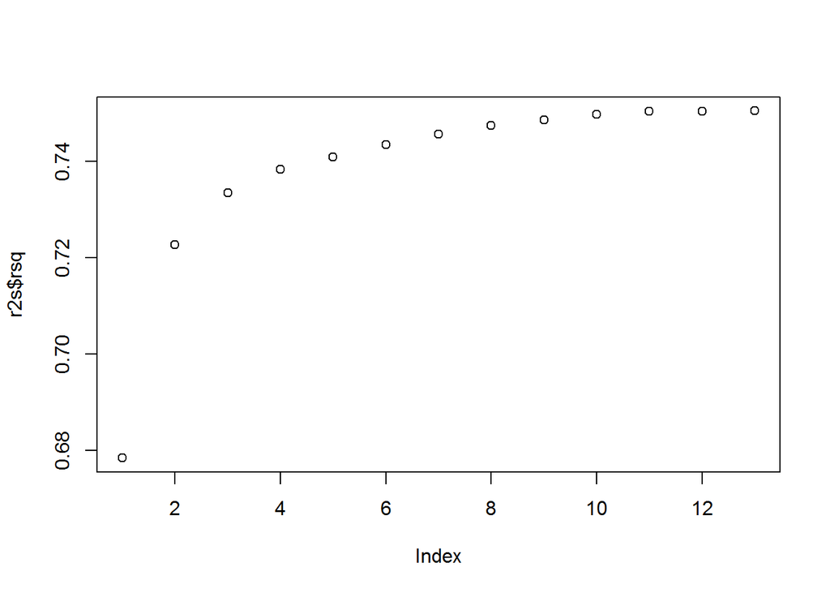

```r
plot(r2s$rsq)
```

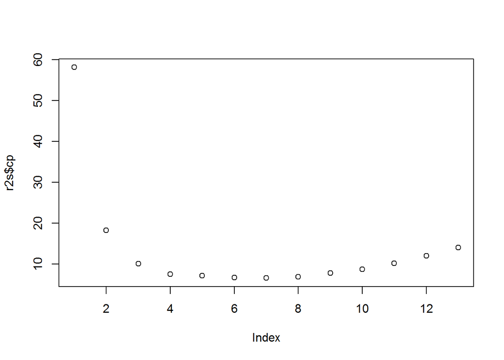

```r
plot(r2s$cp)
```

```r
which.min(r2s$cp)
```

```
## [1] 7
```

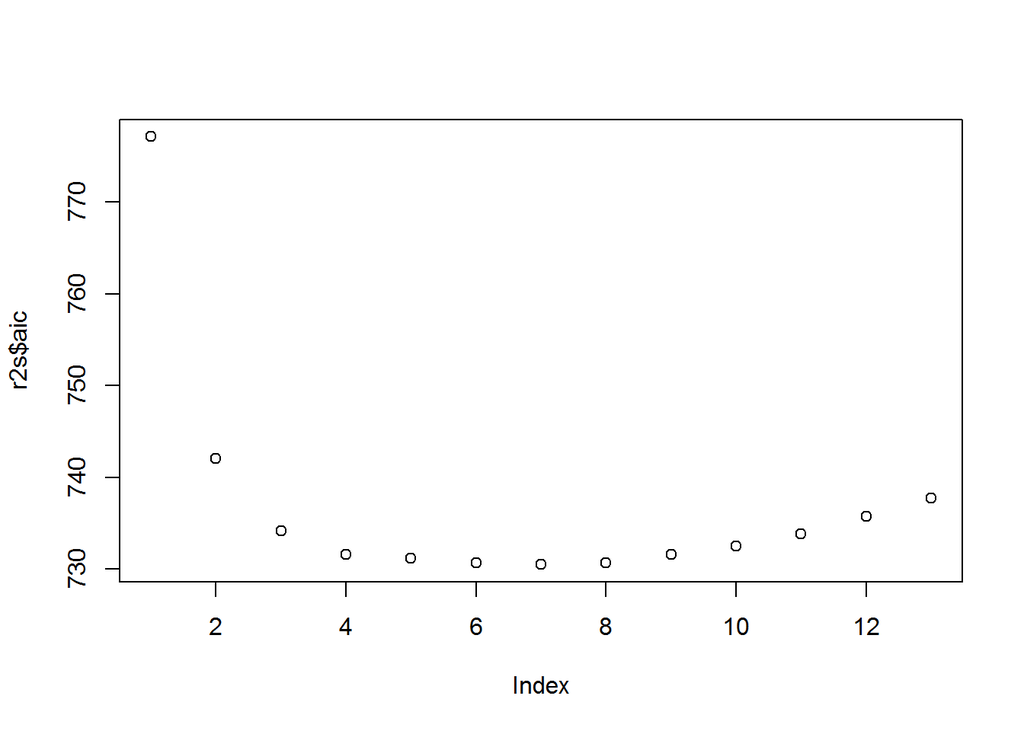

```r
plot(r2s$aic)
```

```r
which.min(r2s$aic)
```

```
## [1] 7
```

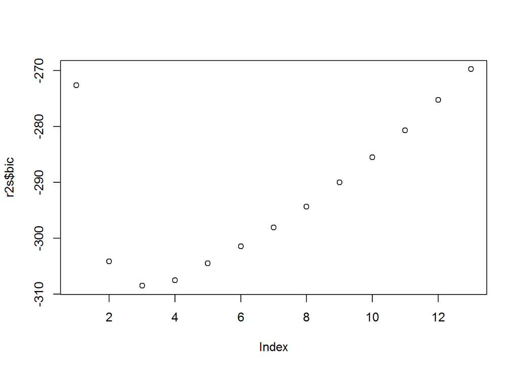

```r
plot(r2s$bic)
```

```r
which.min(r2s$bic)
```

```
## [1] 3
```

Note `r2s$rsq` increases as the model gets larger. It will always do this, and this makes it not useful for model selection, since it will always favor the largest model, which we know not to be a sensible general idea. The Cp criterion and AIC both favor the model with 7 variables, and bic favors the model with 3 variables. (We told you it favors more parsimonious models than AIC!)

Here are some more things you can calculate and plots you can make:

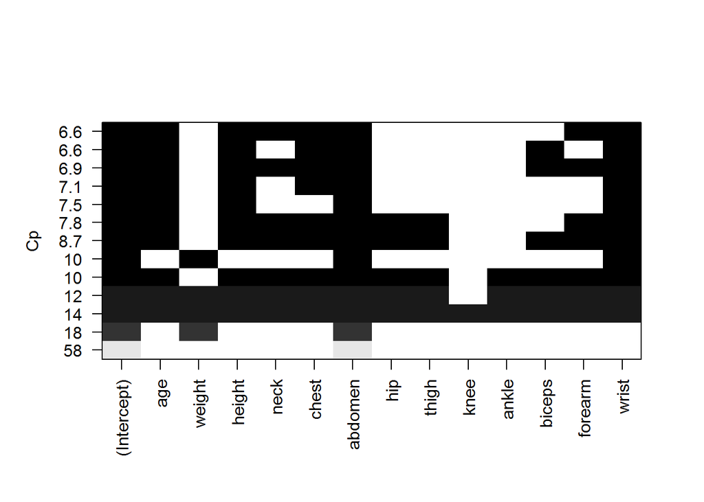

```r
plot(r2, scale="Cp") # best models are on top
```

```r
which.min(r2s$cp) # best model has 7 variables plus intercept.
```

```
## [1] 7
```

```r
# Let's look at the model Cp and AIC like best:
bestwhich <- r2s$which[7,]
bestwhich
```

```
## (Intercept)         age      weight      height        neck       chest
##        TRUE        TRUE       FALSE        TRUE        TRUE        TRUE
##     abdomen         hip       thigh        knee       ankle      biceps
##        TRUE       FALSE       FALSE       FALSE       FALSE       FALSE
##     forearm       wrist
##        TRUE        TRUE
```

```r
X <- mall$model
names(X)
```

```
##  [1] "bf"      "age"     "weight"  "height"  "neck"    "chest"   "abdomen"
##  [8] "hip"     "thigh"   "knee"    "ankle"   "biceps"  "forearm" "wrist"
```

```r
mbestAIC <- lm(bf ~ ., data=X[,bestwhich])
mbestAIC
```

```
##
## Call:
## lm(formula = bf ~ ., data = X[, bestwhich])
##
## Coefficients:
## (Intercept)          age       height         neck        chest
##     5.22127      0.06097     -0.32158     -0.32320     -0.13283
##     abdomen      forearm        wrist
##     0.87058      0.35935     -1.71930
```

```r
extractAIC(mbestAIC)
```

```
## [1]   8.000 730.483
```

```r
extractAIC(msb)
```

```
## [1]   9.0000 731.2669
```

Yes, indeed, the best model of all in terms of Cp does have a slightly lower AIC than the best we have seen so far using the greedy stepwise procedures.

If regression is used for prediction, the model selection problem is not terribly serious. We can just pick any one of the many good models and use it, and it’s best not to view the model that happens to win the AIC competition as “the best” model dominating all the others in its utter superiority. For prediction it doesn’t matter which good prediction is used. But if regression is used for more for explanation, such as problems of causality, then the model selection problem is more difficult and it’s hard to be definitive.

```r
order(r2s$aic, decreasing = TRUE)
```

```
##  [1]  1  2 13 12  3 11 10  4  9  5  8  6  7
```

```r
order(r2s$cp, decreasing = TRUE)
```

```
##  [1]  1  2 13 12 11  3 10  9  4  5  8  6  7
```

```r
# aic and cp do not give exactly the same order (contrary to
# some claims on the web).
```